# Um relatório em cima de EDA SIP

Dandara Sousa

22 de abril de 2019

```r
estimativas_raw = read_projectdata()
```

## Conhecendo os dados

```r
estimativas_raw %>%
    select(ProjectCode, TaskNumber, HoursEstimate, HoursActual) %>%
    skimr::skim()
```

```
## Skim summary statistics
##  n obs: 12299
##  n variables: 4
##
## -- Variable type:character -------------------------------------------------------------------------------
##     variable missing complete     n min max empty n_unique
##  ProjectCode       0    12299 12299   3   4     0       20
##   TaskNumber       0    12299 12299   4   5     0    10266
##
## -- Variable type:numeric ---------------------------------------------------------------------------------
##       variable missing complete     n  mean    sd   p0 p25 p50 p75    p100
##    HoursActual       0    12299 12299 13.18 68.72 0.01   1   3 8.5 2490.16
##  HoursEstimate       0    12299 12299 10.15 28.84 0.01   1   3 7    910
##      hist
##  ▇▁▁▁▁▁▁▁
##  ▇▁▁▁▁▁▁▁
```

#### 1 estimativa por task

Para nossa análise, usaremos uma estimativa por task. Caso haja mais de uma usaremos a média das estimativas_raw:

```r
estimativas <- estimativas_raw %>%
    group_by(ProjectCode, TaskNumber, Category, Priority, Summary) %>%
    summarise(
        HoursEstimate = mean(HoursEstimate),
        HoursActual = mean(HoursActual),
        DeveloperPerformance = mean(DeveloperPerformance)
    ) %>%
    ungroup()
```

#### Dados por time

```r
por_time <- estimativas_raw %>%
    group_by(ProjectCode) %>%
    summarise(devs = NROW(unique(DeveloperID)),
              erro_medio_abs = mean(abs(HoursEstimate - HoursActual)),
              estimativas = n())
```

## Questionamentos acerca dos dados

Com nossos dados organizados, esse é o momento para explorar e adquirir informações.

#### Qual a relação entre as estimativas e horas reais tomadas na empresa como um todo e em diferentes categorias de tarefa?

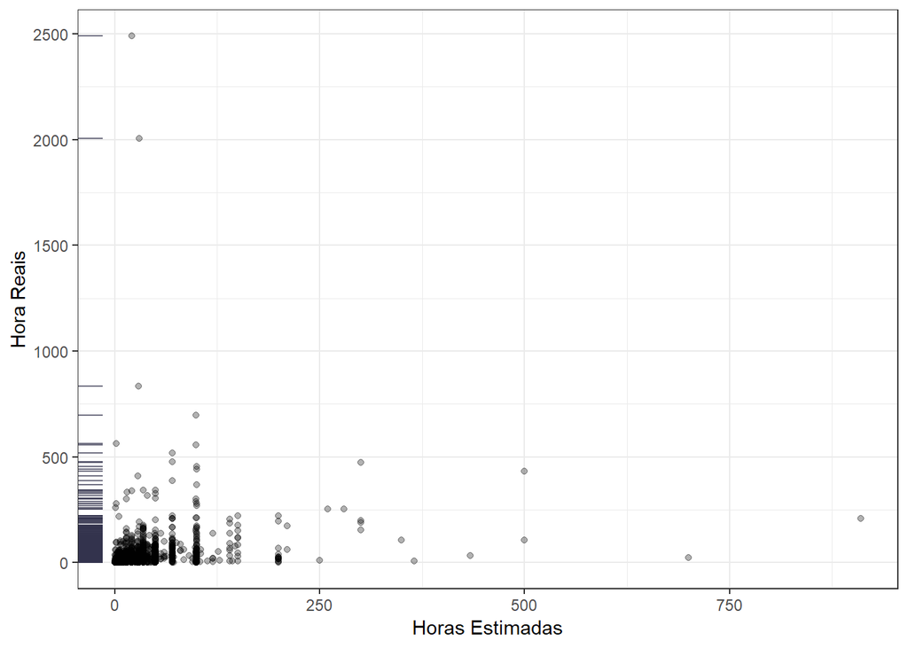

```r
estimativas %>%
    ggplot(aes(HoursEstimate, HoursActual))+
    geom_point(alpha = .3) +
    geom_rug(alpha = .7, color = "#33334d", sides = "l") +
    labs(
        x = "Horas Estimadas",
        y = "Hora Reais" )
```

Para uma primeira visualização geral temos um gráfico de pontos. É possível perceber que os valores em sua maioria são baixos e alguns extremos são localizados. Para tentar encontrar uma relação entre os dados vamos colocar x e y em log2.

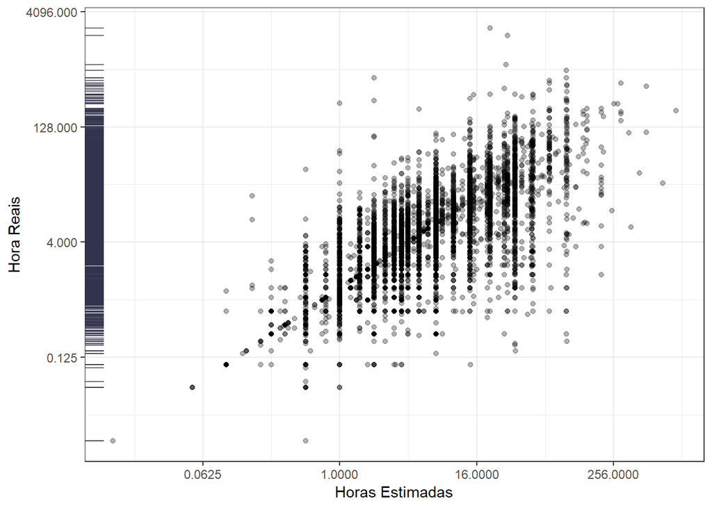

```r
estimativas %>%
    ggplot(aes(HoursEstimate, HoursActual)) +
    geom_point(alpha = .3) +
    geom_rug(alpha = .7, color = "#33334d", sides = "l") +
    scale_x_continuous(trans = "log2") +
    scale_y_continuous(trans = "log2") +
    labs(
        x = "Horas Estimadas",
        y = "Hora Reais" )
```

Por último, vamos ver estatisticamente a correlação entre as variáveis. Pearson, um método bom para observar correlações lineares não aponta uma correlação forte neste caso. Isso é esperado uma vez que ao lidarmos com escala linear não conseguimos extrair muito dos dados. A correlação de Spearman e Kendall lindam com rankings, para Spearman é mais forte do que em Kendall.

```r
estimativas %>%
    summarise(
        Pearson = cor(HoursEstimate, HoursActual, method = "pearson"),
        Spearman = cor(HoursEstimate, HoursActual, method = "spearman"),
        Kendall = cor(HoursEstimate, HoursActual, method = "kendall")
    )
```

```
## # A tibble: 1 x 3
##   Pearson Spearman Kendall
##     <dbl>    <dbl>   <dbl>
## 1   0.316    0.826   0.696
```

Agora, seguindo a mesma ideia para uma análise por categoria de task, vamos ver a correlação e visualizar a relação.

```r
estimativas %>%
    group_by(Category) %>%
    summarise(
        Pearson = cor(HoursEstimate, HoursActual, method = "pearson"),
        Spearman = cor(HoursEstimate, HoursActual, method = "spearman"),
        Kendall = cor(HoursEstimate, HoursActual, method = "kendall")
    )
```

```
## # A tibble: 3 x 4
##   Category    Pearson Spearman Kendall
##   <chr>         <dbl>    <dbl>   <dbl>
## 1 Development   0.377    0.835   0.700
## 2 Management    0.456    0.753   0.635
## 3 Operational   0.159    0.842   0.729
```

Vemos que de certa forma o padrão anterior se repete para as correlações. Pearson sendo fraca e Spearman a mais forte. Veremos então se visualmente o padrão se repete.

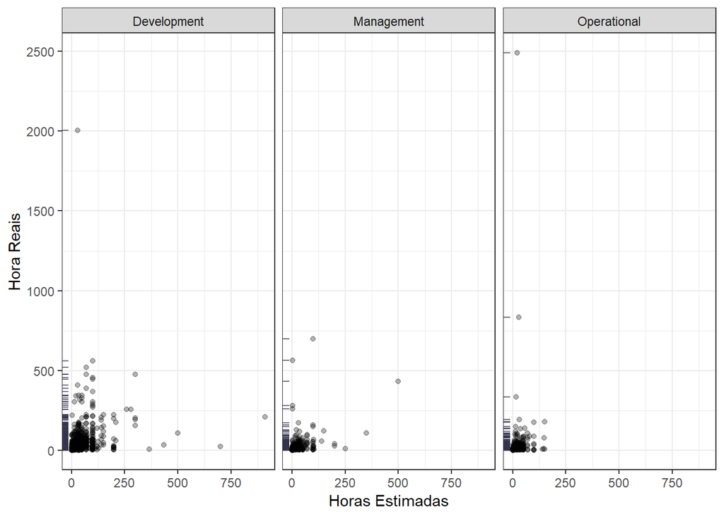

```r
estimativas %>%
    group_by(Category) %>%
    ggplot(aes(HoursEstimate, HoursActual))+
    geom_point(alpha = .3) +
    geom_rug(alpha = .7, color = "#33334d", sides = "l") +
    facet_wrap(~Category) +
    labs(
        x = "Horas Estimadas",
        y = "Hora Reais" )
```

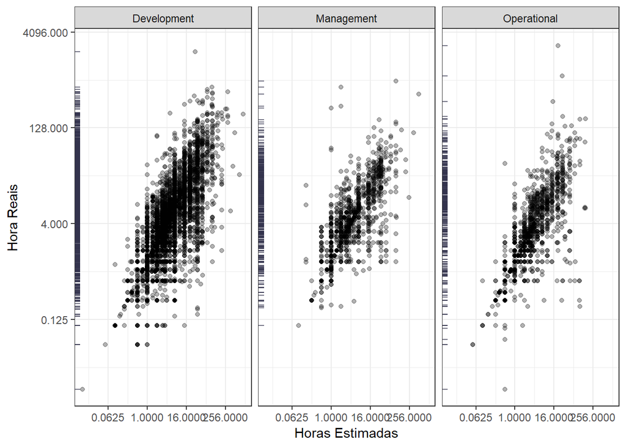

```r
estimativas %>%
    group_by(Category) %>%
    ggplot(aes(HoursEstimate, HoursActual)) +
    geom_point(alpha = .3) +
    geom_rug(alpha = .7, color = "#33334d", sides = "l") +
    scale_x_continuous(trans = "log2") +
    scale_y_continuous(trans = "log2") +
    facet_wrap(~Category) +
    labs(
        x = "Horas Estimadas",
        y = "Hora Reais" )
```

Novamente, o padrão se repete. Vemos uma relação que linearmente não parece ser fácil de identificar mas quando mudamos para escala logarítima conseguimos enxergar uma relação positiva e crescente.

#### Equipes com mais desenvolvedores produzem estimativas com mais ou menos erro que equipes menores?

Primeiro, olhando a correlação entre as variáveis temos que, diferente das estimativas a correlação é baixa ou até negativa no caso de Pearson.

```r
por_time %>%
    summarise(
        Pearson = cor(erro_medio_abs, devs, method = "pearson"),
        Spearman = cor(erro_medio_abs, devs, method = "spearman"),
        Kendall = cor(erro_medio_abs, devs, method = "kendall")
    )
```

```
## # A tibble: 1 x 3
##   Pearson Spearman Kendall
##     <dbl>    <dbl>   <dbl>
## 1  -0.137   0.0438  0.0324
```

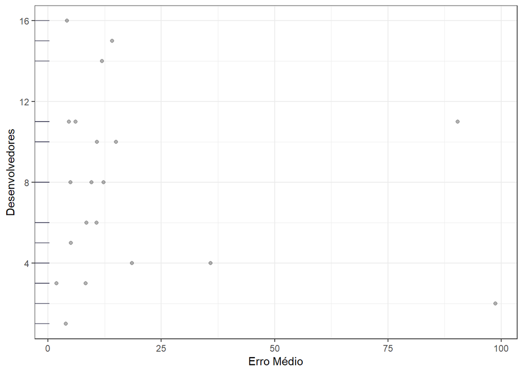

```r
por_time %>%
    ggplot(aes(erro_medio_abs, devs)) +
    geom_point(alpha = .3) +
    geom_rug(alpha = .7, color = "#33334d", sides = "l") +
    labs(
        x = "Erro Médio",
        y = "Desenvolvedores" )
```

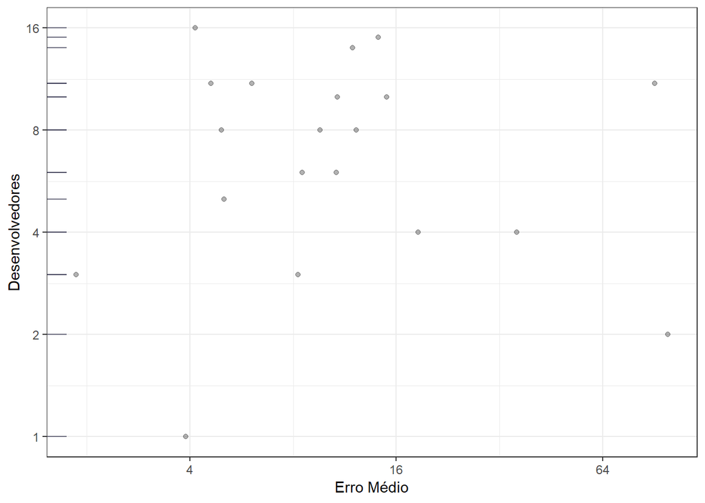

```r
por_time %>%
    ggplot(aes(erro_medio_abs, devs)) +
    geom_point(alpha = .3) +
    geom_rug(alpha = .7, color = "#33334d", sides = "l") +
    scale_x_continuous(trans = "log2") +
    scale_y_continuous(trans = "log2") +
    labs(
        x = "Erro Médio",
        y = "Desenvolvedores" )
```

Realmente, não parece há uma correlação entre as variáveis. Visualmente a distribuição pode-se dizer que não segue um padrão nem quando colocada na escala logarítima.